```python
from IPython.display import Image
from IPython.core.display import HTML
Image(url= "https://www.noticebard.com/wp-content/uploads/2017/04/christ.jpg", height=500)
```

[figure not shown]

# **CIA 3**

## **Programming with Python**

## *Task Assigned*

## Exploratory data analysis on a dataset and preprocessing

## *Dataset Choosen*

## **Employee Attrition Dataset**

### *SUBMISSION BY*,

### BADAL SONI

### 1928608

```python
from IPython.display import Image
from IPython.core.display import HTML
Image(url= "https://www.techfunnel.com/wp-content/uploads/2020/04/employee-attrition.jpg",width=800, height=800)
```

[figure not shown]

# CRISP DM Methodology

```python
from IPython.display import Image
from IPython.core.display import HTML
Image(url= "https://storage.ning.com/topology/rest/1.0/file/get/2023380?profile=RESIZE_1024x1024", width=800, height=800)
```

[figure not shown]

# CRISP DM Methodology

### Business Understanding

Attrition in an organisation is the biggest problem in an indstry because it doesnot just effect the workforce balance but also has serious implication on the effectiveness, adds extra cost of train. A municipality corporation plays a very vital role in the maintenance and improvement of cities and towns. They do not merely maintain the city but it is key in the functioning and working of the cities. The key challenges that the municipalities face are accountability, efficiency, delayed and extended lead time for projects, poor quality of work in projects. Making sure that all the funds are adequately raised and the best budget is drafted so that development projects can be funded.

### Data Understanding

The data is collected from Kaggle.The data is consists of 4504 rowsa and 20 Columns. The attributes and essentials details regarding an employee is listed in each column they are Age, attrition, businessTravel, department, distanceFromHome, educationField, employeeID, gender, job Level, job Role, maritalStatus, MonthlyIncome, over18, PercentSalaryHike, StandardHours, StockOptionLevel, TrainingTimesLastYear, YearsAtCompany, YearsSinceLastPromotion and YearsWithCurrManager

### Data Preparation

###### Selecting Data

The data is sourced from Kaggle.

###### Data Cleaning

The data collected from the Kaggle needed pre-processing and deriving columns. The dataset was did not ahve much cleaning part because there was no missing values.

### Modeling.

The modeling is was done using random forest classifier.

### Evaluation

```python
#Import Libraries
import numpy as np
import pandas as pd
import seaborn as sns
import matplotlib.pyplot as plt
%matplotlib inline
```

```python
df = pd.read_csv("C:\\Users\\Admin\\Downloads\\Attrition.csv")
df.head(5) #Print the first 5 rows
```

|  | Age | Attrition | BusinessTravel | Department | DistanceFromHome | EducationField | EmployeeID | Gender | JobLevel | JobRole | MaritalStatus | MonthlyIncome | Over18 | PercentSalaryHike | StandardHours | StockOptionLevel | TrainingTimesLastYear | YearsAtCompany | YearsSinceLastPromotion | YearsWithCurrManager |
| --- | --- | --- | --- | --- | --- | --- | --- | --- | --- | --- | --- | --- | --- | --- | --- | --- | --- | --- | --- | --- |
| 0 | 51 | No | Travel_Rarely | Sales | 6 | Life Sciences | 1 | Female | 1 | Healthcare Representative | Married | 131160 | Y | 11 | 8 | 0 | 6 | 1 | 0 | 0 |
| 1 | 31 | Yes | Travel_Frequently | Research & Development | 10 | Life Sciences | 2 | Female | 1 | Research Scientist | Single | 41890 | Y | 23 | 8 | 1 | 3 | 5 | 1 | 4 |
| 2 | 32 | No | Travel_Frequently | Research & Development | 17 | Other | 3 | Male | 4 | Sales Executive | Married | 193280 | Y | 15 | 8 | 3 | 2 | 5 | 0 | 3 |
| 3 | 38 | No | Non-Travel | Research & Development | 2 | Life Sciences | 4 | Male | 3 | Human Resources | Married | 83210 | Y | 11 | 8 | 3 | 5 | 8 | 7 | 5 |
| 4 | 32 | No | Travel_Rarely | Research & Development | 10 | Medical | 5 | Male | 1 | Sales Executive | Single | 23420 | Y | 12 | 8 | 2 | 2 | 6 | 0 | 4 |

```python
#Get the number of rows and number of columns in the data
df.shape
```

```
(4504, 20)
```

```python
#Get the column data types
df.dtypes
```

```
Age                         int64
Attrition                  object
BusinessTravel             object
Department                 object
DistanceFromHome            int64
EducationField             object
EmployeeID                  int64
Gender                     object
JobLevel                    int64
JobRole                    object
MaritalStatus              object
MonthlyIncome               int64
Over18                     object
PercentSalaryHike           int64
StandardHours               int64
StockOptionLevel            int64
TrainingTimesLastYear       int64
YearsAtCompany              int64
YearsSinceLastPromotion     int64
YearsWithCurrManager        int64
dtype: object
```

```python
#Count the empty (NaN, NAN, na) values in each column
df.isna().sum()
```

```
Age                        0
Attrition                  0
BusinessTravel             0
Department                 0
DistanceFromHome           0
EducationField             0
EmployeeID                 0
Gender                     0
JobLevel                   0
JobRole                    0
MaritalStatus              0
MonthlyIncome              0
Over18                     0
PercentSalaryHike          0
StandardHours              0
StockOptionLevel           0
TrainingTimesLastYear      0
YearsAtCompany             0
YearsSinceLastPromotion    0
YearsWithCurrManager       0
dtype: int64
```

```python
df.info()
```

```
<class 'pandas.core.frame.DataFrame'>
RangeIndex: 4504 entries, 0 to 4503
Data columns (total 20 columns):
Age                        4504 non-null int64
Attrition                  4504 non-null object
BusinessTravel             4504 non-null object
Department                 4504 non-null object
DistanceFromHome           4504 non-null int64
EducationField             4504 non-null object
EmployeeID                 4504 non-null int64
Gender                     4504 non-null object
JobLevel                   4504 non-null int64
JobRole                    4504 non-null object
MaritalStatus              4504 non-null object
MonthlyIncome              4504 non-null int64
Over18                     4504 non-null object
PercentSalaryHike          4504 non-null int64
StandardHours              4504 non-null int64
StockOptionLevel           4504 non-null int64
TrainingTimesLastYear      4504 non-null int64
YearsAtCompany             4504 non-null int64
YearsSinceLastPromotion    4504 non-null int64
YearsWithCurrManager       4504 non-null int64
dtypes: int64(12), object(8)
memory usage: 703.8+ KB
```

```python
#Another check for any null / missing values
df.isnull().values.any()
```

```
False
```

```python
# Basic Summary statistics like mean, median, Std. deviation, Min, Max and percentiles.
df.describe()
```

|  | Age | DistanceFromHome | EmployeeID | JobLevel | MonthlyIncome | PercentSalaryHike | StandardHours | StockOptionLevel | TrainingTimesLastYear | YearsAtCompany | YearsSinceLastPromotion | YearsWithCurrManager |
| --- | --- | --- | --- | --- | --- | --- | --- | --- | --- | --- | --- | --- |
| count | 4504.000000 | 4504.000000 | 4504.000000 | 4504.000000 | 4504.000000 | 4504.000000 | 4504.0 | 4504.000000 | 4504.000000 | 4504.000000 | 4504.000000 | 4504.000000 |
| mean | 36.927620 | 9.216918 | 2195.408970 | 2.060169 | 65052.537744 | 15.221359 | 8.0 | 0.792185 | 2.797291 | 7.031972 | 2.196270 | 4.140542 |
| std | 9.144295 | 8.120964 | 1285.372834 | 1.103634 | 47081.537166 | 3.663454 | 0.0 | 0.851053 | 1.286594 | 6.156509 | 3.236084 | 3.581792 |
| min | 18.000000 | 1.000000 | 1.000000 | 1.000000 | 10090.000000 | 11.000000 | 8.0 | 0.000000 | 0.000000 | 0.000000 | 0.000000 | 0.000000 |
| 25% | 30.000000 | 2.000000 | 1059.750000 | 1.000000 | 29090.000000 | 12.000000 | 8.0 | 0.000000 | 2.000000 | 3.000000 | 0.000000 | 2.000000 |
| 50% | 36.000000 | 7.000000 | 2185.500000 | 2.000000 | 49080.000000 | 14.000000 | 8.0 | 1.000000 | 3.000000 | 5.000000 | 1.000000 | 3.000000 |
| 75% | 43.000000 | 14.000000 | 3311.250000 | 3.000000 | 83810.000000 | 18.000000 | 8.0 | 1.000000 | 3.000000 | 10.000000 | 3.000000 | 7.000000 |
| max | 60.000000 | 29.000000 | 4410.000000 | 5.000000 | 199990.000000 | 25.000000 | 8.0 | 3.000000 | 6.000000 | 40.000000 | 15.000000 | 17.000000 |

```python
# To get a count of the number of employee attrition whether they stayed (No) and the employees who left (Yes)
df['Attrition'].value_counts()
```

```
No     3782
Yes     722
Name: Attrition, dtype: int64
```

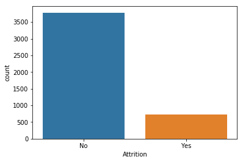

```python
#Visualization to get a count of the number of employee attrition whether they stayed (No) and the employees who left (Yes)
sns.countplot(df['Attrition'])
```

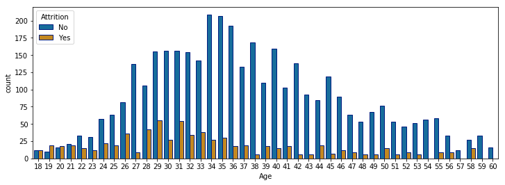

```python
#Graph Showing the number of employees those sayed and left by age
import matplotlib.pyplot as plt
fig_dims = (12, 4)
fig, ax = plt.subplots(figsize=fig_dims)

#ax = axis
sns.countplot(x='Age', hue='Attrition', data = df, palette="colorblind", ax = ax,  edgecolor=sns.color_palette("dark", n_colors = 1));
```

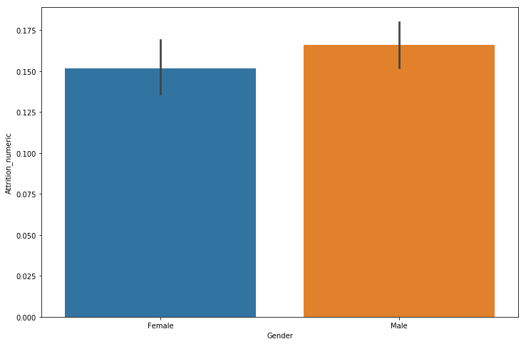

```python
# convert to numeric for mean
df.Attrition_numeric = df.Attrition
df.loc[df.Attrition == 'Yes','Attrition_numeric'] = 1
df.loc[df.Attrition == 'No','Attrition_numeric'] = 0

plt.figure(figsize=(12,8))
sns.barplot(x = 'Gender', y = 'Attrition_numeric', data=df)
```

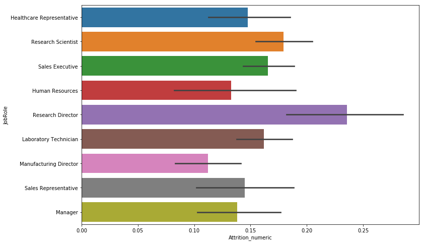

```python
plt.figure(figsize=(12,8))
sns.barplot(y = 'JobRole', x = 'Attrition_numeric', data=df)
```

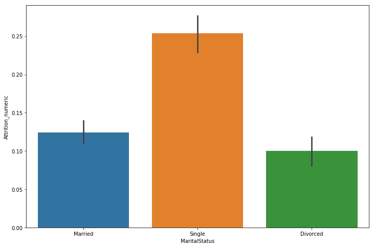

```python
# attrition by marital status
plt.figure(figsize=(12,8))
sns.barplot(x = 'MaritalStatus', y = 'Attrition_numeric', data=df)
```

```python
#Printimg all of the object data types and their unique values
for column in df.columns:
    if df[column].dtype == object:
        print(str(column) + ' : ' + str(df[column].unique()))
        print(df[column].value_counts())
        print("_________________________________________________________________")
```

```
Attrition : ['No' 'Yes']
No     3782
Yes     722
Name: Attrition, dtype: int64
_________________________________________________________________
BusinessTravel : ['Travel_Rarely' 'Travel_Frequently' 'Non-Travel']
Travel_Rarely        3198
Travel_Frequently     849
Non-Travel            457
Name: BusinessTravel, dtype: int64
_________________________________________________________________
Department : ['Sales' 'Research & Development' 'Human Resources']
Research & Development    2938
Sales                     1371
Human Resources            195
Name: Department, dtype: int64
_________________________________________________________________
EducationField : ['Life Sciences' 'Other' 'Medical' 'Marketing' 'Technical Degree'
 'Human Resources']
Life Sciences       1858
Medical             1418
Marketing            491
Technical Degree     402
Other                252
Human Resources       83
Name: EducationField, dtype: int64
_________________________________________________________________
Gender : ['Female' 'Male']
Male      2705
Female    1799
Name: Gender, dtype: int64
_________________________________________________________________
JobRole : ['Healthcare Representative' 'Research Scientist' 'Sales Executive'
 'Human Resources' 'Research Director' 'Laboratory Technician'
 'Manufacturing Director' 'Sales Representative' 'Manager']
Sales Executive              996
Research Scientist           898
Laboratory Technician        798
Manufacturing Director       446
Healthcare Representative    400
Manager                      311
Sales Representative         255
Research Director            242
Human Resources              158
Name: JobRole, dtype: int64
_________________________________________________________________
MaritalStatus : ['Married' 'Single' 'Divorced']
Married     2059
Single      1438
Divorced    1007
Name: MaritalStatus, dtype: int64
_________________________________________________________________
Over18 : ['Y']
Y    4504
Name: Over18, dtype: int64
_________________________________________________________________
```

```python
#Remove unnecessary columns
#Remove the column EmployeeNumber
df = df.drop('EmployeeID', axis = 1) # A number assignment
#Remove the column StandardHours
df = df.drop('StandardHours', axis = 1) #Contains only value 80
#Remove the column EmployeeCount
df = df.drop('Over18', axis = 1) #Contains only the value 'Yes'
```

```python
#Get the correlation of each of the columns
df.corr()
```

|  | Age | DistanceFromHome | JobLevel | MonthlyIncome | PercentSalaryHike | StockOptionLevel | TrainingTimesLastYear | YearsAtCompany | YearsSinceLastPromotion | YearsWithCurrManager | Attrition_numeric |
| --- | --- | --- | --- | --- | --- | --- | --- | --- | --- | --- | --- |
| Age | 1.000000 | 0.005188 | -0.003705 | -0.041333 | -0.032535 | -0.028557 | -0.025144 | 0.313506 | 0.217281 | 0.204085 | -0.160485 |
| DistanceFromHome | 0.005188 | 1.000000 | -0.037930 | -0.020421 | 0.036163 | 0.006813 | -0.007863 | 0.032730 | 0.005123 | 0.019054 | -0.007200 |
| JobLevel | -0.003705 | -0.037930 | 1.000000 | 0.048654 | 0.011096 | -0.000871 | -0.032072 | -0.066109 | -0.061011 | -0.056970 | -0.008468 |
| MonthlyIncome | -0.041333 | -0.020421 | 0.048654 | 1.000000 | 0.006738 | 0.025637 | 0.048131 | 0.001533 | 0.067248 | 0.026308 | -0.032132 |
| PercentSalaryHike | -0.032535 | 0.036163 | 0.011096 | 0.006738 | 1.000000 | 0.008134 | -0.039620 | -0.025983 | -0.025844 | -0.038826 | 0.029106 |
| StockOptionLevel | -0.028557 | 0.006813 | -0.000871 | 0.025637 | 0.008134 | 1.000000 | -0.065253 | 0.009406 | 0.019732 | 0.021531 | -0.007081 |
| TrainingTimesLastYear | -0.025144 | -0.007863 | -0.032072 | 0.048131 | -0.039620 | -0.065253 | 1.000000 | -0.003892 | 0.016545 | -0.010683 | -0.048285 |
| YearsAtCompany | 0.313506 | 0.032730 | -0.066109 | 0.001533 | -0.025983 | 0.009406 | -0.003892 | 1.000000 | 0.621779 | 0.768529 | -0.134197 |
| YearsSinceLastPromotion | 0.217281 | 0.005123 | -0.061011 | 0.067248 | -0.025844 | 0.019732 | 0.016545 | 0.621779 | 1.000000 | 0.513367 | -0.035480 |
| YearsWithCurrManager | 0.204085 | 0.019054 | -0.056970 | 0.026308 | -0.038826 | 0.021531 | -0.010683 | 0.768529 | 0.513367 | 1.000000 | -0.156042 |
| Attrition_numeric | -0.160485 | -0.007200 | -0.008468 | -0.032132 | 0.029106 | -0.007081 | -0.048285 | -0.134197 | -0.035480 | -0.156042 | 1.000000 |

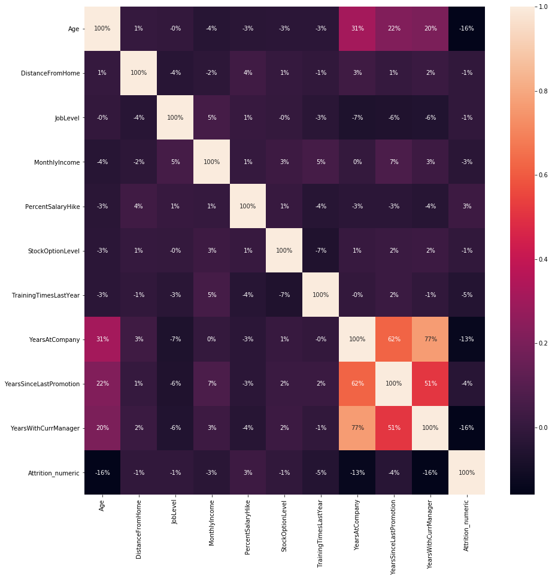

```python
#Visualization of correlation in a heat map
plt.figure(figsize=(15,15))  #14in by 14in
sns.heatmap(df.corr(), annot=True, fmt='.0%')
```

```python
#Transform non-numeric columns into numerical columns
from sklearn.preprocessing import LabelEncoder

for column in df.columns:
        if df[column].dtype == np.number:
            continue
        df[column] = LabelEncoder().fit_transform(df[column])
```

```python
#Create a new column at the end of the dataframe that contains the same value
df['Age_Years'] = df['Age']
#Remove the first column called age
df = df.drop('Age', axis = 1)
#Show the dataframe
df
```

|  | Attrition | BusinessTravel | Department | DistanceFromHome | EducationField | Gender | JobLevel | JobRole | MaritalStatus | MonthlyIncome | PercentSalaryHike | StockOptionLevel | TrainingTimesLastYear | YearsAtCompany | YearsSinceLastPromotion | YearsWithCurrManager | Attrition_numeric | Age_Years |
| --- | --- | --- | --- | --- | --- | --- | --- | --- | --- | --- | --- | --- | --- | --- | --- | --- | --- | --- |
| 0 | 0 | 2 | 2 | 5 | 1 | 0 | 0 | 0 | 1 | 1166 | 0 | 0 | 6 | 1 | 0 | 0 | 0.0 | 33 |
| 1 | 1 | 1 | 1 | 9 | 1 | 0 | 0 | 6 | 2 | 505 | 12 | 1 | 3 | 5 | 1 | 4 | 1.0 | 13 |
| 2 | 0 | 1 | 1 | 16 | 4 | 1 | 3 | 7 | 1 | 1318 | 4 | 3 | 2 | 5 | 0 | 3 | 0.0 | 14 |
| 3 | 0 | 0 | 1 | 1 | 1 | 1 | 2 | 1 | 1 | 984 | 0 | 3 | 5 | 8 | 7 | 5 | 0.0 | 20 |
| 4 | 0 | 2 | 1 | 9 | 3 | 1 | 0 | 7 | 2 | 145 | 1 | 2 | 2 | 6 | 0 | 4 | 0.0 | 14 |
| 5 | 0 | 2 | 1 | 7 | 1 | 0 | 3 | 5 | 1 | 486 | 2 | 0 | 5 | 7 | 7 | 7 | 0.0 | 28 |
| 6 | 1 | 2 | 1 | 10 | 3 | 1 | 1 | 7 | 2 | 792 | 9 | 1 | 2 | 0 | 0 | 0 | 1.0 | 10 |
| 7 | 0 | 2 | 1 | 17 | 1 | 1 | 1 | 7 | 1 | 353 | 11 | 3 | 2 | 0 | 0 | 0 | 0.0 | 11 |
| 8 | 0 | 2 | 1 | 0 | 1 | 1 | 2 | 2 | 1 | 46 | 10 | 0 | 2 | 9 | 7 | 8 | 0.0 | 13 |
| 9 | 0 | 0 | 1 | 6 | 3 | 0 | 3 | 2 | 0 | 1183 | 2 | 1 | 2 | 6 | 1 | 5 | 0.0 | 7 |
| 10 | 0 | 2 | 1 | 16 | 3 | 1 | 1 | 2 | 1 | 973 | 2 | 2 | 2 | 20 | 4 | 10 | 0.0 | 27 |
| 11 | 0 | 2 | 1 | 27 | 1 | 1 | 0 | 2 | 1 | 384 | 1 | 2 | 2 | 15 | 10 | 11 | 0.0 | 18 |
| 12 | 0 | 2 | 1 | 13 | 1 | 0 | 0 | 7 | 2 | 757 | 6 | 0 | 2 | 34 | 4 | 13 | 0.0 | 37 |
| 13 | 1 | 0 | 1 | 0 | 3 | 1 | 0 | 6 | 1 | 783 | 0 | 2 | 4 | 10 | 9 | 9 | 1.0 | 29 |
| 14 | 0 | 2 | 1 | 0 | 1 | 1 | 0 | 4 | 1 | 217 | 3 | 0 | 2 | 5 | 0 | 4 | 0.0 | 10 |
| 15 | 0 | 2 | 1 | 0 | 1 | 1 | 1 | 0 | 1 | 721 | 0 | 0 | 2 | 5 | 0 | 1 | 0.0 | 19 |
| 16 | 0 | 2 | 1 | 2 | 1 | 1 | 0 | 2 | 2 | 511 | 1 | 3 | 3 | 3 | 1 | 0 | 0.0 | 3 |
| 17 | 0 | 0 | 1 | 0 | 3 | 1 | 1 | 7 | 0 | 497 | 2 | 1 | 2 | 5 | 0 | 2 | 0.0 | 19 |
| 18 | 0 | 2 | 2 | 6 | 1 | 1 | 0 | 8 | 0 | 176 | 5 | 0 | 5 | 7 | 6 | 2 | 0.0 | 17 |
| 19 | 0 | 2 | 1 | 7 | 1 | 0 | 0 | 3 | 0 | 912 | 0 | 1 | 5 | 8 | 7 | 7 | 0.0 | 20 |
| 20 | 0 | 1 | 1 | 0 | 4 | 1 | 1 | 2 | 0 | 1097 | 7 | 0 | 3 | 6 | 1 | 4 | 0.0 | 8 |
| 21 | 0 | 2 | 2 | 7 | 1 | 1 | 0 | 6 | 0 | 1046 | 12 | 0 | 2 | 10 | 1 | 6 | 0.0 | 32 |
| 22 | 0 | 2 | 1 | 10 | 1 | 0 | 1 | 6 | 1 | 80 | 0 | 0 | 2 | 5 | 1 | 3 | 0.0 | 35 |
| 23 | 0 | 2 | 1 | 3 | 1 | 1 | 0 | 4 | 1 | 1017 | 3 | 0 | 4 | 20 | 11 | 6 | 0.0 | 24 |
| 24 | 0 | 1 | 1 | 15 | 3 | 1 | 0 | 2 | 2 | 865 | 0 | 1 | 2 | 10 | 0 | 9 | 0.0 | 11 |
| 25 | 0 | 2 | 1 | 0 | 4 | 0 | 0 | 6 | 1 | 900 | 0 | 0 | 2 | 10 | 0 | 8 | 0.0 | 37 |
| 26 | 0 | 1 | 1 | 8 | 1 | 0 | 0 | 3 | 1 | 1230 | 11 | 0 | 3 | 5 | 3 | 3 | 0.0 | 8 |
| 27 | 0 | 2 | 2 | 4 | 2 | 1 | 0 | 6 | 2 | 252 | 0 | 0 | 2 | 17 | 5 | 7 | 0.0 | 19 |
| 28 | 1 | 1 | 1 | 0 | 3 | 1 | 1 | 6 | 0 | 1089 | 3 | 1 | 2 | 1 | 0 | 0 | 1.0 | 26 |
| 29 | 0 | 2 | 2 | 1 | 2 | 0 | 0 | 3 | 0 | 563 | 1 | 0 | 3 | 2 | 1 | 2 | 0.0 | 20 |
| ... | ... | ... | ... | ... | ... | ... | ... | ... | ... | ... | ... | ... | ... | ... | ... | ... | ... | ... |
| 4474 | 0 | 2 | 1 | 2 | 5 | 0 | 1 | 0 | 0 | 633 | 5 | 1 | 2 | 7 | 1 | 7 | 0.0 | 11 |
| 4475 | 0 | 2 | 2 | 8 | 3 | 0 | 1 | 2 | 1 | 262 | 4 | 1 | 3 | 1 | 0 | 0 | 0.0 | 16 |
| 4476 | 0 | 2 | 1 | 3 | 1 | 0 | 0 | 2 | 1 | 523 | 7 | 0 | 2 | 22 | 3 | 10 | 0.0 | 26 |
| 4477 | 0 | 2 | 1 | 7 | 1 | 0 | 1 | 6 | 0 | 1229 | 2 | 1 | 2 | 9 | 0 | 8 | 0.0 | 15 |
| 4478 | 0 | 2 | 2 | 1 | 2 | 1 | 2 | 2 | 2 | 1143 | 11 | 0 | 0 | 1 | 0 | 1 | 0.0 | 1 |
| 4479 | 0 | 2 | 2 | 1 | 3 | 1 | 2 | 2 | 1 | 30 | 2 | 1 | 2 | 1 | 0 | 1 | 0.0 | 5 |
| 4480 | 1 | 1 | 1 | 0 | 1 | 1 | 0 | 4 | 2 | 1130 | 0 | 1 | 3 | 1 | 1 | 0 | 1.0 | 7 |
| 4481 | 0 | 2 | 0 | 8 | 1 | 1 | 1 | 6 | 2 | 902 | 0 | 1 | 4 | 8 | 2 | 2 | 0.0 | 8 |
| 4482 | 1 | 2 | 0 | 11 | 0 | 1 | 1 | 2 | 2 | 531 | 0 | 2 | 3 | 24 | 1 | 11 | 1.0 | 27 |
| 4483 | 0 | 0 | 1 | 26 | 1 | 0 | 1 | 3 | 0 | 642 | 13 | 1 | 3 | 32 | 15 | 0 | 0.0 | 37 |
| 4484 | 1 | 1 | 1 | 19 | 3 | 0 | 3 | 6 | 2 | 719 | 3 | 1 | 2 | 2 | 2 | 2 | 1.0 | 3 |
| 4485 | 0 | 2 | 1 | 0 | 1 | 1 | 0 | 4 | 1 | 143 | 2 | 1 | 2 | 11 | 0 | 8 | 0.0 | 28 |
| 4486 | 0 | 2 | 2 | 12 | 3 | 1 | 2 | 8 | 2 | 944 | 3 | 1 | 3 | 3 | 0 | 2 | 0.0 | 16 |
| 4487 | 0 | 1 | 1 | 13 | 1 | 1 | 1 | 5 | 0 | 1106 | 3 | 0 | 3 | 28 | 11 | 10 | 0.0 | 33 |
| 4488 | 0 | 2 | 1 | 3 | 1 | 1 | 1 | 6 | 2 | 1237 | 10 | 1 | 2 | 9 | 5 | 4 | 0.0 | 41 |
| 4489 | 0 | 1 | 2 | 13 | 3 | 0 | 2 | 6 | 0 | 1011 | 2 | 1 | 1 | 11 | 5 | 10 | 0.0 | 16 |
| 4490 | 0 | 1 | 1 | 1 | 4 | 0 | 0 | 3 | 2 | 760 | 8 | 0 | 3 | 4 | 0 | 2 | 0.0 | 10 |
| 4491 | 0 | 2 | 1 | 2 | 1 | 1 | 1 | 6 | 0 | 611 | 6 | 0 | 4 | 25 | 14 | 13 | 0.0 | 26 |
| 4492 | 0 | 1 | 2 | 0 | 1 | 1 | 1 | 7 | 1 | 165 | 7 | 1 | 3 | 10 | 1 | 8 | 0.0 | 16 |
| 4493 | 0 | 2 | 1 | 8 | 1 | 1 | 3 | 0 | 1 | 1057 | 8 | 0 | 2 | 3 | 2 | 2 | 0.0 | 17 |
| 4494 | 0 | 2 | 1 | 22 | 1 | 0 | 0 | 3 | 1 | 858 | 2 | 0 | 3 | 1 | 0 | 0 | 0.0 | 24 |
| 4495 | 0 | 2 | 1 | 6 | 3 | 0 | 0 | 2 | 2 | 1325 | 7 | 2 | 3 | 21 | 15 | 17 | 0.0 | 25 |
| 4496 | 0 | 2 | 1 | 1 | 3 | 1 | 0 | 0 | 2 | 260 | 10 | 1 | 4 | 16 | 5 | 12 | 0.0 | 18 |
| 4497 | 1 | 2 | 1 | 20 | 1 | 0 | 1 | 2 | 1 | 836 | 8 | 1 | 3 | 10 | 0 | 5 | 1.0 | 26 |
| 4498 | 0 | 1 | 1 | 1 | 1 | 0 | 1 | 8 | 1 | 73 | 3 | 0 | 3 | 2 | 2 | 2 | 0.0 | 10 |
| 4499 | 0 | 1 | 2 | 20 | 3 | 1 | 1 | 6 | 2 | 1283 | 6 | 0 | 3 | 7 | 7 | 7 | 0.0 | 33 |
| 4500 | 0 | 0 | 1 | 1 | 4 | 1 | 0 | 6 | 2 | 64 | 0 | 3 | 2 | 8 | 1 | 7 | 0.0 | 12 |
| 4501 | 1 | 2 | 1 | 28 | 5 | 0 | 0 | 8 | 0 | 308 | 2 | 0 | 4 | 7 | 7 | 7 | 1.0 | 11 |
| 4502 | 0 | 2 | 2 | 0 | 1 | 0 | 1 | 8 | 2 | 44 | 4 | 1 | 5 | 3 | 1 | 2 | 0.0 | 10 |
| 4503 | 0 | 2 | 1 | 17 | 1 | 1 | 0 | 6 | 2 | 421 | 14 | 0 | 0 | 2 | 2 | 1 | 0.0 | 7 |

4504 rows × 18 columns

```python
#Spliting  the data into independent 'X' and dependent 'Y' variables
X = df.iloc[:, 1:df.shape[1]].values
Y = df.iloc[:, 0].values
```

```python
# Split the dataset into 70% Training set and 30% Testing set
from sklearn.model_selection import train_test_split
X_train, X_test, Y_train, Y_test = train_test_split(X, Y, test_size = 0.30, random_state = 0)
```

```python
#Use Random Forest Classification algorithm
from sklearn.ensemble import RandomForestClassifier
forest = RandomForestClassifier(n_estimators = 10, criterion = 'entropy', random_state = 0)
forest.fit(X_train, Y_train)
```

```
RandomForestClassifier(bootstrap=True, class_weight=None, criterion='entropy',
            max_depth=None, max_features='auto', max_leaf_nodes=None,
            min_impurity_decrease=0.0, min_impurity_split=None,
            min_samples_leaf=1, min_samples_split=2,
            min_weight_fraction_leaf=0.0, n_estimators=10, n_jobs=None,
            oob_score=False, random_state=0, verbose=0, warm_start=False)
```

```python
#Get the accuracy on the training data
forest.score(X_train, Y_train)
```

```
1.0
```

```python
#Show the confusion matrix and accuracy for  the model on the test data
#Classification accuracy is the ratio of correct predictions to total predictions made.
from sklearn.metrics import confusion_matrix

cm = confusion_matrix(Y_test, forest.predict(X_test))

TN = cm[0][0]
TP = cm[1][1]
FN = cm[1][0]
FP = cm[0][1]

print(cm)
print('Model Testing Accuracy = "{}!"'.format(  (TP + TN) / (TP + TN + FN + FP)))
print()# Print a new line
```

```
[[1128    0]
 [   0  224]]
Model Testing Accuracy = "1.0!"
```

```python
# Return the feature importances (the higher, the more important the feature).
importances = pd.DataFrame({'feature':df.iloc[:, 1:df.shape[1]].columns,'importance':np.round(forest.feature_importances_,3)}) #Note: The target column is at position 0
importances = importances.sort_values('importance',ascending=False).set_index('feature')
importances
```

| feature | importance |
| --- | --- |
| Attrition_numeric | 0.805 |
| YearsAtCompany | 0.033 |
| MonthlyIncome | 0.021 |
| Age_Years | 0.021 |
| MaritalStatus | 0.020 |
| DistanceFromHome | 0.016 |
| YearsWithCurrManager | 0.013 |
| PercentSalaryHike | 0.010 |
| TrainingTimesLastYear | 0.010 |
| JobRole | 0.009 |
| StockOptionLevel | 0.008 |
| EducationField | 0.007 |
| YearsSinceLastPromotion | 0.007 |
| BusinessTravel | 0.007 |
| JobLevel | 0.005 |
| Department | 0.005 |
| Gender | 0.002 |

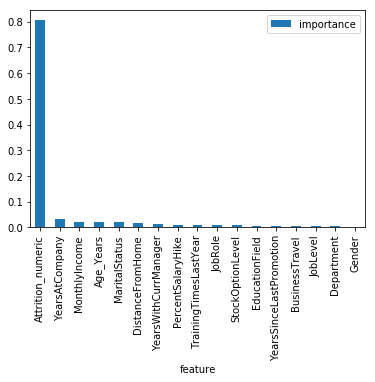

```python
#Visualize the importance
importances.plot.bar()
```

# Deriving useful insights

#### 3. The total attrition at the company is 722.

#### 4. Most the employees are Sales executive and research scientist.

#### 5. Most of the employees have a background of medical or life sciences.

# Learnings from the assignment

#### 1. Got a good understanding of the Dataset

#### 2. understood how Random Forest Algorithm can be used as a classifier to predict the attrition.

#### 3. Understood the basics of Exploratory data analysis.

#### 4. Got a fair understanding of Python libraries like Pandas, Numpy, Seaborn and Matlibplot